# PhD Plus Data Literacy in R

Session 1: An Introduction to R

Clay Ford

University of Virginia Library, StatLab

## Why R?

- Designed to investigate and analyze data.
- Free and open source.
- In active development; always evolving and improving.
- Lots of resources available for learning R.
- Welcoming and supportive community.

## R and RStudio

- I recommend you use R with RStudio Desktop.
- R and RStudio are separate programs. Do not need RStudio to use R, but it sure makes it easier.
- R is supported by The R Foundation, a not-for-profit organization.
- RStudio Desktop is a free product provided by Posit, an “open source data science company”.

## Installing R and RStudio

This page provides instructions for downloading and installing R and RStudio.

https://clayford.github.io/r_install/

Once R and RStudio are both installed, **you only need to run RStudio**.

## Functions

- You tell R what to do using *functions*. For example, to take the square root of 2 use the `sqrt()` function. The number 2 is the function *argument*.

```r
sqrt(2)
```

```
[1] 1.414214
```

- Functions can have multiple *arguments*. For example, the `round()` function has two arguments: the value to round and the number of digits to round to.

```r
round(sqrt(2), digits = 3)
```

```
[1] 1.414
```

Notice we used `sqrt(2)` as the input to `round()`.

## Assignment

We often want to save a result instead of viewing it in the Console. We can do this with the *assignment operator*: `<-`

```r
s2 <- sqrt(2)
```

**Tip**

Use `Alt + -` (Win) or `Option + -` (Mac) in RStudio to quickly insert `<-`. You can also use `=` for assignment.

Now we can work with the *named object*.

```r
round(s2, 4)
```

```
[1] 1.4142
```

Notice we didn’t have to use `digits = 4`. We can use *unnamed arguments* if we use them in the correct order.

## Naming rules

R is *case sensitive*. “Dat”, “DAT”, and “dat” are all considered different names.

You can name an object in R almost anything you want, but it cannot…

- start with a number
- use certain special symbols, like ^, !, $, @, +, -, /, or *
- contain spaces

However you can use underscores and periods.

**Note**

Strictly speaking, you can break all the rules above by surrounding the name in backticks (``), but that’s not recommended.

## Working in the console

Use your up/down arrow keys to recall previous commands.

Hit `Ctrl + Up` (Win) or `Cmd + Up` (Mac) for a pop-up list of previous commands.

Hit `Ctrl + L` to clear the console.

Hit `Esc` if you get the continuation prompt `+`. This means you have submitted an incomplete command. You can also complete the command, which is usually a closing parenthesis.

## R scripts

In addition to running R code in the console, we can enter it into a *R script* and save the code. A R script is a text file that contains R code.

Start a new R script by going to File…New File…R Script.

Run code in a R script by putting your cursor in the code and hitting `Ctrl + Enter` (Win) or `Cmd + Return` (Mac)

Add comments in a R script by prefacing text with a pound sign, `#`.

## Built-in datasets

R comes with many *datasets* to help us learn R. We can load them using the `data()` function. For example, to load the “trees” data set:

```r
data(trees)
```

This loads a *data frame* called “trees” into memory, or the *Global Environment*.

A data frame is a rectangular data structure where rows represent *observations* and columns represent *variables*. This is a common data structure.

To see all available data sets, go to the Packages tab in RStudio, in the search field enter “datasets”, and click the “datasets” link.

## A few functions for data frames

Calling `summary()` on a data frame returns summary statistics of numeric columns.

```r
summary(trees)
```

```
     Girth           Height       Volume
 Min.   : 8.30   Min.   :63   Min.   :10.20
 1st Qu.:11.05   1st Qu.:72   1st Qu.:19.40
 Median :12.90   Median :76   Median :24.20
 Mean   :13.25   Mean   :76   Mean   :30.17
 3rd Qu.:15.25   3rd Qu.:80   3rd Qu.:37.30
 Max.   :20.60   Max.   :87   Max.   :77.00
```

The `str()` function tells us about the structure of the data frame.

```r
str(trees)
```

```
'data.frame':   31 obs. of  3 variables:
 $ Girth : num  8.3 8.6 8.8 10.5 10.7 10.8 11 11 11.1 11.2 ...
 $ Height: num  70 65 63 72 81 83 66 75 80 75 ...
 $ Volume: num  10.3 10.3 10.2 16.4 18.8 19.7 15.6 18.2 22.6 19.9 ...
```

Calling `plot()` on a data frame returns pairwise scatter plots (not displayed)

```r
plot(trees)
```

## Working with columns in a data frame

Use the `$` operator to extract and work with columns of a data frame. These columns are called *vectors*.

```r
trees$Girth
```

```
 [1]  8.3  8.6  8.8 10.5 10.7 10.8 11.0 11.0 11.1 11.2 11.3 11.4 11.4 11.7 12.0
[16] 12.9 12.9 13.3 13.7 13.8 14.0 14.2 14.5 16.0 16.3 17.3 17.5 17.9 18.0 18.0
[31] 20.6
```

We can enter columns directly into functions. For example:

```r
summary(trees$Girth)
```

```
   Min. 1st Qu.  Median    Mean 3rd Qu.    Max.
   8.30   11.05   12.90   13.25   15.25   20.60
```

```r
mean(trees$Girth)
```

```
[1] 13.24839
```

```r
hist(trees$Girth)
```

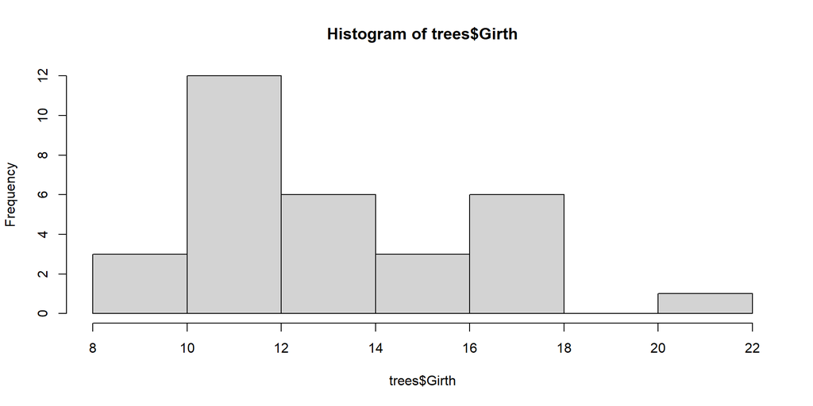

## Working with two columns

We can work directly with two columns. For example, create a scatter plot of Volume versus Girth.

```r
plot(trees$Volume, trees$Girth)
```

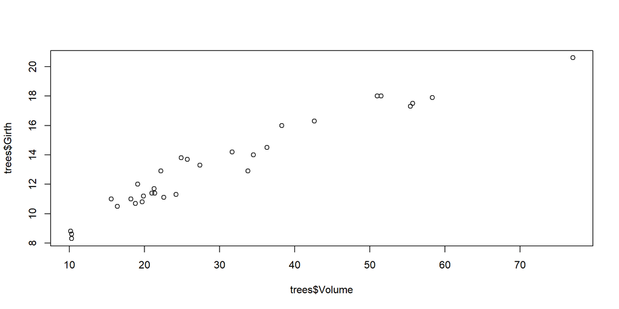

Summarize the linear association in the plot by calculating correlation using the `cor()` function.

```r
cor(trees$Volume, trees$Girth)
```

```
[1] 0.9671194
```

## Comparison

A fundamental concept in data analysis is *comparison*. Comparisons return `TRUE` or `FALSE`.

```r
x <- 12
y <- 8
x > y
```

```
[1] TRUE
```

All comparison operators:

```
x < y
x > y
x <= y
x >= y
x == y
x != y
```

This can be done with columns of a data frame, or *vectors*.

```r
trees$Girth > 13
```

```
 [1] FALSE FALSE FALSE FALSE FALSE FALSE FALSE FALSE FALSE FALSE FALSE FALSE
[13] FALSE FALSE FALSE FALSE FALSE  TRUE  TRUE  TRUE  TRUE  TRUE  TRUE  TRUE
[25]  TRUE  TRUE  TRUE  TRUE  TRUE  TRUE  TRUE
```

## TRUE/FALSE values

TRUE and FALSE values, called *logical* values, are also treated as the numbers 1 and 0, respectively. This allows us to count TRUE values.

How many trees have girth greater than 13?

```r
sum(trees$Girth > 13)
```

```
[1] 14
```

What proportion of trees have girth greater than 13?

```r
mean(trees$Girth > 13)
```

```
[1] 0.4516129
```

How many trees are between 70 and 80 feet tall?

```r
sum(trees$Height > 70 & trees$Height < 80)
```

```
[1] 13
```

`&` (AND) and `|` (OR) are *logical* operators.

## Add/Remove columns to a data frame

To add a column to a data frame, type the new name after the `$` operator and assign the value.

For example, add a column called “Height_m” that contains height of tree in meters by dividing `trees$Height` by 3.281:

```r
trees$Height_m <- trees$Height/3.281
str(trees)
```

```
'data.frame':   31 obs. of  4 variables:
 $ Girth   : num  8.3 8.6 8.8 10.5 10.7 10.8 11 11 11.1 11.2 ...
 $ Height  : num  70 65 63 72 81 83 66 75 80 75 ...
 $ Volume  : num  10.3 10.3 10.2 16.4 18.8 19.7 15.6 18.2 22.6 19.9 ...
 $ Height_m: num  21.3 19.8 19.2 21.9 24.7 ...
```

To remove a column, assign it the value NULL

```r
trees$Height_m <- NULL
```

## Missing data

Missing data in R is represented by `NA` (Not Available). The airquality dataset contains missing data. The Ozone column has 37 missing values.

```r
data(airquality)
summary(airquality$Ozone)
```

```
   Min. 1st Qu.  Median    Mean 3rd Qu.    Max.    NA's
   1.00   18.00   31.50   42.13   63.25  168.00      37
```

Certain functions return `NA` if any data are missing. For example, the `mean()` function:

```r
mean(airquality$Ozone)
```

```
[1] NA
```

Set `na.rm = TRUE` to calculate the mean with the available data:

```r
mean(airquality$Ozone, na.rm = TRUE)
```

```
[1] 42.12931
```

## The `is.na()` function

The `is.na()` function indicates which elements are missing by returning TRUE or FALSE.

For example, the 5th value of Ozone is missing. Notice the 5th value below is TRUE.

```r
head(airquality$Ozone)
```

```
[1] 41 36 12 18 NA 28
```

```r
head(is.na(airquality$Ozone))
```

```
[1] FALSE FALSE FALSE FALSE  TRUE FALSE
```

The `!` operator means NOT. We can use it to find values that are NOT missing.

```r
head(!is.na(airquality$Ozone))
```

```
[1]  TRUE  TRUE  TRUE  TRUE FALSE  TRUE
```

And we can use the result of `is.na()` to calculate summaries about missing values. For example, what proportion of Ozone values is not missing?

```r
mean(!is.na(airquality$Ozone))
```

```
[1] 0.7581699
```

## Vectors

A vector is a one-dimensional data structure consisting of the same data type (number, character, logical). We can create vectors using the `c()` function.

```r
# numeric
ages <- c(29, 25, 28, 45, 33)
# character
gender <- c("m", "m", "f", "f", "m")
```

We can use the `data.frame()` function to create data frames from vectors.

```r
d <- data.frame(ages, gender)
d
```

```
  ages gender
1   29      m
2   25      m
3   28      f
4   45      f
5   33      m
```

Note: the vectors need to be the same *length*.

## Subsetting with brackets

*Subsetting* means selecting rows of a data frame or elements of a vector that meet a certain condition. We can subset vectors and data frames using subsetting brackets. Only values where the result is TRUE are returned.

Show only *values* in the *vector* where Volume is greater than 50:

```r
trees$Volume[trees$Volume > 50]
```

```
[1] 55.4 55.7 58.3 51.5 51.0 77.0
```

```r
trees[trees$Volume > 55, ]
```

[output not shown]

## Subsetting with brackets

We can also subset using numeric vectors to select values/rows.

```r
trees$Volume[c(2, 5, 7)]
```

```
[1] 10.3 18.8 15.6
```

```r
trees$Volume[c(1, 1, 1)]
```

```
[1] 10.3 10.3 10.3
```

```r
trees[c(2, 5, 7),c(1, 3)] # select columns 1 and 3
```

```
  Girth Volume
2   8.6   10.3
5  10.7   18.8
7  11.0   15.6
```

## Subsetting with `subset()`

The `subset()` function is an alternative to using subsetting brackets. Call it on the data frame, and then after the comma define the condition to subset on.

```r
subset(trees, Volume > 55)
```

[output not shown]

```r
subset(airquality, Ozone < 7)
```

```
   Ozone Solar.R Wind Temp Month Day
18     6      78 18.4   57     5  18
21     1       8  9.7   59     5  21
23     4      25  9.7   61     5  23
```

```r
subset(airquality, is.na(Solar.R))
```

```
   Ozone Solar.R Wind Temp Month Day
5     NA      NA 14.3   56     5   5
6     28      NA 14.9   66     5   6
11     7      NA  6.9   74     5  11
27    NA      NA  8.0   57     5  27
96    78      NA  6.9   86     8   4
97    35      NA  7.4   85     8   5
98    66      NA  4.6   87     8   6
```

Notice we do not need to use the `$` operator to refer to columns in the data frame.

## Group summaries

The `tapply()` and `aggregate()` functions allows us to calculate summaries by group. For example, find the the mean temperature for each month in the airquality data.

In this case, `tapply()` returns a vector while `aggregate()` returns a data frame.

```r
tapply(airquality$Temp, airquality$Month, mean)
```

```
       5        6        7        8        9
65.54839 79.10000 83.90323 83.96774 76.90000
```

```r
aggregate(Temp ~ Month, data = airquality, mean) # always returns data frame
```

```
  Month     Temp
1     5 65.54839
2     6 79.10000
3     7 83.90323
4     8 83.96774
5     9 76.90000
```

`aggregate()` uses formula notation. Read `Temp ~ Month` as “Temp grouped by Month”.

## Multiple group summaries

Two use more than one group, wrap the grouping variables in `list()` when using `tapply()`. Notice the result is output as a table.

```r
tapply(mtcars$mpg, list(mtcars$cyl, mtcars$am), mean)
```

```
       0        1
4 22.900 28.07500
6 19.125 20.56667
8 15.050 15.40000
```

Two use more than one group, simply “add” the variables on the right side of the formula using `aggregate()`.

```r
aggregate(mpg ~ cyl + am, data = mtcars, mean)
```

```
  cyl am      mpg
1   4  0 22.90000
2   6  0 19.12500
3   8  0 15.05000
4   4  1 28.07500
5   6  1 20.56667
6   8  1 15.40000
```

These are mean miles per gallon for cars grouped by number of cylinders and whether or not they have automatic transmission.

## Factors

A *factor* is a categorical variable with fixed levels. For example, t-shirt sizes such as S, M, L, and XL.

```r
size <- c("XL", "L", "M", "L", "M")
table(size)
```

```
size
 L  M XL
 2  2  1
```

Convert to factor to set levels and their order.

```r
sizeF <- factor(size, levels = c("S", "M", "L", "XL"))
table(sizeF)
```

```
sizeF
 S  M  L XL
 0  2  2  1
```

## Setting the working directory

Your *working directory* is where R looks for files or outputs files (unless you specify a path). It is listed in the Console header. You can also request it with the `getwd()` function.

If you have ever saved work on your computer to a specific location, then you understand the concept of a working directory.

Go to Session…Set Working Directory…Choose Directory… in RStudio to set your working directory.

You can also use the `setwd()` function with a path specific to your computer. For example, to set my working directory to my Desktop I would run the following:

```r
setwd("/Users/jcf2d/Desktop/")
```

Hitting Tab after `/` or `~/` in RStudio will open a list of available folders and allow you to drill up/down to the desired directory.

## Importing CSV files

CSV files are commonly used for storing data. They are human readable and work on any operating system. They are text files and can be viewed in Excel, Google Sheets, and text editors.

To import a CSV file into R, use the `read.csv()` function. For example, to import a file named “popular_baby_names_nyc.csv” (located in your working directory) into R:

```r
baby_names <- read.csv("popular_baby_names_nyc.csv")
```

Notice we need to assign the result to a name. Any name will do as long as it follows R’s naming conventions.

## Saving a single object

We can save a single object using the `saveRDS()` function. Give the file name an “rds” extension. For example, the following code saves the trees data frame to the current working directory as “trees.rds”.

```r
saveRDS(trees, file = "trees.rds")
```

To load the file, use the `readRDS()` function. Notice we need to assign the result of the function to a name. The name does not have to match the name of the rds file.

```r
treeData <- readRDS("trees.rds")
```

## Saving two or more objects

We can save two or more objects as a single file using the `save()` function. Give the file name an “Rdata” extension. For example, the following code saves the trees and trees2 data frames to the current working directory as “tree_data.Rdata”.

```r
save(trees, trees2, file = "tree_data.Rdata")
```

To load the two objects back into the Global Environment, use the `load()` function.

```r
load("tree_data.Rdata")
```

Note: if there are objects currently in the Global Environment named “trees” and “trees2”, they will be overwritten.

## Saving the entire workspace

We can save the entire workspace using the `save.image()` function. Simply provide the file name with an “Rdata” extension. Unless a path is specified, it will be saved in your current working directory. For example, the following code saves the entire workspace (i.e., all objects in the Global Environment) to the current working directory as “my_workspace.Rdata”.

```r
save.image(file = "my_workspace.RData")
```

To restore the workspace, use the `load()` function.

```r
load("my_workspace.Rdata")
```

Note: if there are any objects currently in the Global Environment with the same name as the objects in “my_workspace.Rdata”, they will be overwritten.

## Installing packages

All functions belong to *packages*. The `read.csv()` function is in the `{utils}` package. R comes with 30 packages (called “base R”), but there are thousands of user-contributed packages.

Example: `{ggplot2}` is a popular package that adds functions for creating graphs in a different way than what base R provides

To use functions in a package, the package must be installed and loaded. (They’re free.) You *install* a package once. You *load* a package whenever you want to use its functions.

To install a package, go to Tools…Install Packages… in RStudio. Or use the `install.packages()` function. To load a package, use the `library()` function. For example:

```r
install.packages("ggplot2") # just need to do once
library(ggplot2)
```

Now `{ggplot2}` functions are available to use.

## Resources

- [fasteR: Fast Lane to Learning R!](https://github.com/matloff/fasteR)
- [Ch 2 of Hands on Programming with R](https://rstudio-education.github.io/hopr/basics.html)
- [Chs 1 and 2 of R for Data Science](https://r4ds.hadley.nz/) (Emphasizes the Tidyverse dialect of R)
- [Getting Started in R: Tinyverse Edition](https://eddelbuettel.github.io/gsir-te/Getting-Started-in-R.pdf)
- [An Introduction to R](https://cran.r-project.org/doc/manuals/r-release/R-intro.html) (The original tutorial from 1990!)
- [RStudio keyboard shortcuts](https://support.posit.co/hc/en-us/articles/200711853-Keyboard-Shortcuts-in-the-RStudio-IDE).